# Practical Machine Learning - Course project

Sergej Horvat

prosinca 2016.

### Background

Using devices such as Jawbone Up, Nike FuelBand, and Fitbit it is now possible to collect a large amount of data about personal activity relatively inexpensively. These type of devices are part of the quantified self movement – a group of enthusiasts who take measurements about themselves regularly to improve their health, to find patterns in their behavior, or because they are tech geeks. One thing that people regularly do is quantify how much of a particular activity they do, but they rarely quantify how well they do it. In this project, your goal will be to use data from accelerometers on the belt, forearm, arm, and dumbell of 6 participants. They were asked to perform barbell lifts correctly and incorrectly in 5 different ways. More information is available from the website here: http://groupware.les.inf.puc-rio.br/har (see the section on the Weight Lifting Exercise Dataset).

### Data

The training data for this project are available here:

https://d396qusza40orc.cloudfront.net/predmachlearn/pml-training.csv

The test data are available here:

https://d396qusza40orc.cloudfront.net/predmachlearn/pml-testing.csv

The data for this project come from this source: http://groupware.les.inf.puc-rio.br/har. If you use the document you create for this class for any purpose please cite them as they have been very generous in allowing their data to be used for this kind of assignment.

### What you should submit

The goal of your project is to predict the manner in which they did the exercise. This is the “classe” variable in the training set. You may use any of the other variables to predict with. * You should create a report describing how you built your model, * how you used cross validation, * what you think the expected out of sample error is, * and why you made the choices you did. * You will also use your prediction model to predict 20 different test cases.

#### Peer Review Portion

Your submission for the Peer Review portion should consist of a link to a Github repo with your R markdown and compiled HTML file describing your analysis. Please constrain the text of the writeup to < 2000 words and the number of figures to be less than 5. It will make it easier for the graders if you submit a repo with a gh-pages branch so the HTML page can be viewed online (and you always want to make it easy on graders :-).

#### Course Project Prediction Quiz Portion

Apply your machine learning algorithm to the 20 test cases available in the test data above and submit your predictions in appropriate format to the Course Project Prediction Quiz for automated grading.

### Reproducibility

Due to security concerns with the exchange of R code, your code will not be run during the evaluation by your classmates. Please be sure that if they download the repo, they will be able to view the compiled HTML version of your analysis.

```r
# Load trining and test data
pml.train <- read.csv("D://+Coursera//+Data Science//+Practical Machine Learning//Week 4//pml-training.csv")

pml.test <- read.csv("D://+Coursera//+Data Science//+Practical Machine Learning//Week 4//pml-testing.csv")

# Lets see some data
str(pml.train)
```

```
## 'data.frame':    19622 obs. of  160 variables:
##  $ X                       : int  1 2 3 4 5 6 7 8 9 10 ...
##  $ user_name               : Factor w/ 6 levels "adelmo","carlitos",..: 2 2 2 2 2 2 2 2 2 2 ...
##  $ raw_timestamp_part_1    : int  1323084231 1323084231 1323084231 1323084232 1323084232 1323084232 1323084232 1323084232 1323084232 1323084232 ...
##  $ raw_timestamp_part_2    : int  788290 808298 820366 120339 196328 304277 368296 440390 484323 484434 ...
##  $ cvtd_timestamp          : Factor w/ 20 levels "02/12/2011 13:32",..: 9 9 9 9 9 9 9 9 9 9 ...
##  $ new_window              : Factor w/ 2 levels "no","yes": 1 1 1 1 1 1 1 1 1 1 ...
##  $ num_window              : int  11 11 11 12 12 12 12 12 12 12 ...
##  $ roll_belt               : num  1.41 1.41 1.42 1.48 1.48 1.45 1.42 1.42 1.43 1.45 ...
##  $ pitch_belt              : num  8.07 8.07 8.07 8.05 8.07 8.06 8.09 8.13 8.16 8.17 ...
##  $ yaw_belt                : num  -94.4 -94.4 -94.4 -94.4 -94.4 -94.4 -94.4 -94.4 -94.4 -94.4 ...
##  $ total_accel_belt        : int  3 3 3 3 3 3 3 3 3 3 ...
##  $ kurtosis_roll_belt      : Factor w/ 397 levels "","-0.016850",..: 1 1 1 1 1 1 1 1 1 1 ...
##  $ kurtosis_picth_belt     : Factor w/ 317 levels "","-0.021887",..: 1 1 1 1 1 1 1 1 1 1 ...
##  $ kurtosis_yaw_belt       : Factor w/ 2 levels "","#DIV/0!": 1 1 1 1 1 1 1 1 1 1 ...
```

[output cut: 86 more lines]

### Random forest model with all raw data from all sensors

```r
## RANDOM FOREST MODELS

library(randomForest)
set.seed(1)
pml.train.rf <- randomForest(classe ~
                        roll_belt+pitch_belt+yaw_belt+total_accel_belt+
                        gyros_belt_x+gyros_belt_y+gyros_belt_z+
                        accel_belt_x+accel_belt_y+accel_belt_z+
                        magnet_belt_x+magnet_belt_y+magnet_belt_z+
                        roll_arm+pitch_arm+yaw_arm+
                        gyros_arm_x+gyros_arm_y+gyros_arm_z+
                        accel_arm_x+accel_arm_y+accel_arm_z+
                        magnet_arm_x+magnet_arm_y+magnet_arm_z+
                        roll_dumbbell+pitch_dumbbell+yaw_dumbbell+total_accel_dumbbell+
                        gyros_dumbbell_x+gyros_dumbbell_y+gyros_dumbbell_z+
                        accel_dumbbell_x+accel_dumbbell_y+accel_dumbbell_z+
                        magnet_dumbbell_x+magnet_dumbbell_y+magnet_dumbbell_z+
                        roll_forearm+pitch_forearm+yaw_forearm+total_accel_forearm+
                        gyros_forearm_x+gyros_forearm_y+gyros_forearm_z+
                        accel_forearm_x+accel_forearm_y+accel_forearm_z+
                        magnet_forearm_x+magnet_forearm_y+magnet_forearm_z,
                        data=pml.train,
                        method="rf",
                        importance=TRUE,
                        na.action = na.omit)

# Print the training model data
print(pml.train.rf)
```

```
##
## Call:
##  randomForest(formula = classe ~ roll_belt + pitch_belt + yaw_belt +      total_accel_belt + gyros_belt_x + gyros_belt_y + gyros_belt_z +      accel_belt_x + accel_belt_y + accel_belt_z + magnet_belt_x +      magnet_belt_y + magnet_belt_z + roll_arm + pitch_arm + yaw_arm +      gyros_arm_x + gyro…
##                Type of random forest: classification
##                      Number of trees: 500
## No. of variables tried at each split: 7
##
##         OOB estimate of  error rate: 0.28%
## Confusion matrix:
##      A    B    C    D    E  class.error
## A 5578    1    0    0    1 0.0003584229
## B   12 3782    3    0    0 0.0039504872
## C    0   11 3409    2    0 0.0037989480
## D    0    0   18 3196    2 0.0062189055
## E    0    0    1    3 3603 0.0011089548
```

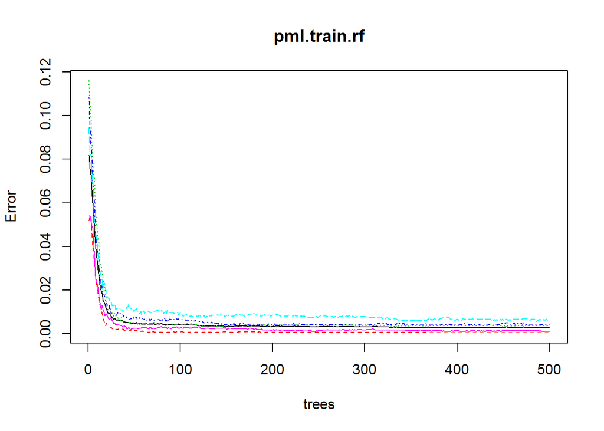

```r
plot(pml.train.rf)
```

```r
# Print variable importance
round(importance(pml.train.rf),2)
```

```
##                          A     B     C     D     E MeanDecreaseAccuracy
## roll_belt            40.02 51.53 47.40 47.57 44.11                57.98
## pitch_belt           33.26 53.90 44.13 35.85 35.74                54.74
## yaw_belt             48.37 46.87 46.27 50.78 34.35                65.00
## total_accel_belt     14.47 17.54 15.60 16.18 16.21                18.40
## gyros_belt_x         19.37 19.59 21.27 16.64 20.15                30.28
## gyros_belt_y         11.66 18.17 16.85 17.54 19.52                21.56
## gyros_belt_z         21.10 28.39 25.40 22.41 26.93                29.81
## accel_belt_x         14.18 18.42 16.91 13.26 14.23                19.76
## accel_belt_y         12.70 16.27 13.88 16.26 14.85                18.49
## accel_belt_z         24.93 26.07 26.02 23.66 20.85                31.19
## magnet_belt_x        18.19 28.99 27.94 22.51 27.55                35.44
## magnet_belt_y        24.12 30.40 29.08 28.06 26.19                32.31
## magnet_belt_z        23.31 28.26 24.74 28.77 23.97                30.01
## roll_arm             22.14 33.21 29.41 30.27 23.14                36.43
## pitch_arm            19.50 26.44 22.23 22.12 18.64                27.55
## yaw_arm              24.63 27.54 25.42 28.25 22.35                32.66
## gyros_arm_x          18.56 29.91 24.85 25.88 26.59                29.91
## gyros_arm_y          22.49 33.06 27.19 27.70 25.27                40.62
## gyros_arm_z          12.97 21.90 18.25 16.30 15.62                26.56
## accel_arm_x          17.05 20.64 20.39 24.20 17.96                22.36
## accel_arm_y          17.43 23.81 19.04 19.80 18.31                26.90
## accel_arm_z          13.04 22.28 23.45 22.57 18.55                21.66
## magnet_arm_x         18.23 17.66 20.90 19.70 16.51                19.81
## magnet_arm_y         12.59 18.86 19.78 22.09 13.80                18.30
## magnet_arm_z         21.71 28.98 25.17 22.40 21.45                31.25
## roll_dumbbell        23.54 29.19 29.20 29.32 27.45                31.26
## pitch_dumbbell       12.64 21.13 17.97 14.73 15.56                19.39
## yaw_dumbbell         19.33 26.87 24.68 24.11 24.59                29.76
## total_accel_dumbbell 19.35 25.61 19.65 22.43 26.23                26.72
## gyros_dumbbell_x     18.34 28.02 22.33 20.37 20.94                31.88
## gyros_dumbbell_y     22.01 23.37 29.19 22.81 20.42                27.13
## gyros_dumbbell_z     19.88 26.79 20.93 20.91 16.93                39.18
## accel_dumbbell_x     17.39 24.51 19.67 20.65 20.09                23.44
## accel_dumbbell_y     26.14 32.10 31.36 29.87 29.68                36.74
## accel_dumbbell_z     21.56 28.12 26.81 25.59 28.26                32.60
## magnet_dumbbell_x    25.87 26.65 30.21 26.89 23.47                29.44
## magnet_dumbbell_y    34.93 38.06 46.47 38.01 34.67                43.70
## magnet_dumbbell_z    41.41 39.24 48.29 36.50 35.91                47.80
## roll_forearm         31.09 26.91 33.94 25.35 25.19                31.35
```

[output cut: 49 more lines]

```
## magnet_dumbbell_y              701.30
## magnet_dumbbell_z              757.85
## roll_forearm                   611.71
## pitch_forearm                  788.68
## yaw_forearm                    176.68
## total_accel_forearm            108.37
## gyros_forearm_x                 73.27
## gyros_forearm_y                127.27
## gyros_forearm_z                 84.53
## accel_forearm_x                324.28
## accel_forearm_y                139.45
## accel_forearm_z                245.62
## magnet_forearm_x               228.69
## magnet_forearm_y               216.42
## magnet_forearm_z               288.42
```

```r
# Predict from RANDOM FOREST MODEL
pml.test.predict <- predict(pml.train.rf,pml.test)
print(pml.test.predict)
```

```
##  1  2  3  4  5  6  7  8  9 10 11 12 13 14 15 16 17 18 19 20
##  B  A  B  A  A  E  D  B  A  A  B  C  B  A  E  E  A  B  B  B
## Levels: A B C D E
```

With approach to use all data that has values results in accurate model OOB error only 0.28% (test data quiz 20/20). but is this proper model with that many predictors? This leads to large amount of sensors and data to be processed. Could we build a model that needs less number of predictors to get god accuracy. So less sensors and data to process is needed.

```r
#Build new random forest model
pml.train.rf2 <- randomForest(classe ~
                                      roll_belt+
                                      pitch_belt+
                                      yaw_belt+
                                      total_accel_belt+
                                      gyros_belt_x+
                                      gyros_belt_y+
                                      gyros_belt_z+
                                      accel_belt_x+
                                      accel_belt_y+
                                      accel_belt_z+
                                      magnet_belt_x+
                                      magnet_belt_y+
                                      magnet_belt_z+
                                      roll_arm+
                                      pitch_arm+
                                      yaw_arm,
                                      data=pml.train,
                                      method="rf",
                                      importance=TRUE,
                                      na.action = na.omit)

# Print the training model data
print(pml.train.rf2)
```

```
##
## Call:
##  randomForest(formula = classe ~ roll_belt + pitch_belt + yaw_belt +      total_accel_belt + gyros_belt_x + gyros_belt_y + gyros_belt_z +      accel_belt_x + accel_belt_y + accel_belt_z + magnet_belt_x +      magnet_belt_y + magnet_belt_z + roll_arm + pitch_arm + yaw_arm,      data = pml.train, m…
##                Type of random forest: classification
##                      Number of trees: 500
## No. of variables tried at each split: 4
##
##         OOB estimate of  error rate: 3.32%
## Confusion matrix:
##      A    B    C    D    E class.error
## A 5431   49   60   31    9  0.02670251
## B   69 3659   47   17    5  0.03634448
## C  106   91 3175   48    2  0.07218001
## D   30    8   22 3149    7  0.02083333
## E   37    5    5    4 3556  0.01413917
```

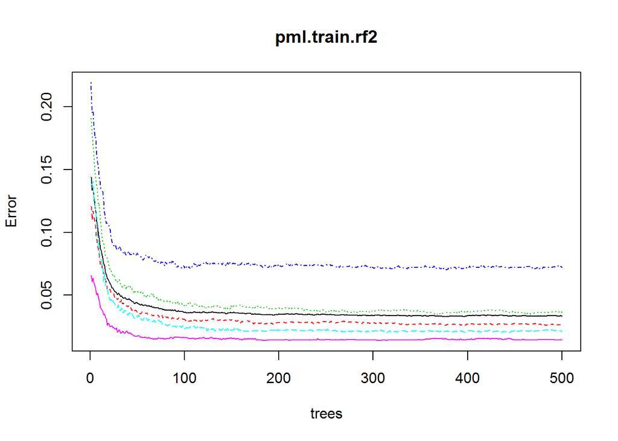

```r
plot(pml.train.rf2)
```

```r
pml.test.predict2 <- predict(pml.train.rf2,pml.test)
pml.test.predict
```

```
##  1  2  3  4  5  6  7  8  9 10 11 12 13 14 15 16 17 18 19 20
##  B  A  B  A  A  E  D  B  A  A  B  C  B  A  E  E  A  B  B  B
## Levels: A B C D E
```

```r
pml.test.predict2
```

```
##  1  2  3  4  5  6  7  8  9 10 11 12 13 14 15 16 17 18 19 20
##  B  A  B  A  A  E  D  B  A  A  B  C  B  A  E  E  A  B  B  B
## Levels: A B C D E
```

```r
# Are result the same as first model?
pml.test.predict2 == pml.test.predict
```

```
##  [1] TRUE TRUE TRUE TRUE TRUE TRUE TRUE TRUE TRUE TRUE TRUE TRUE TRUE TRUE
## [15] TRUE TRUE TRUE TRUE TRUE TRUE
```

Ok, lets try even less predictors , only with the belt data, meaning one sensor only!

```r
#Build new random forest model
pml.train.rf3 <- randomForest(classe ~
                                      roll_belt+
                                      pitch_belt+
                                      yaw_belt+
                                      total_accel_belt+
                                      gyros_belt_x+
                                      gyros_belt_y+
                                      gyros_belt_z+
                                      accel_belt_x+
                                      accel_belt_y+
                                      accel_belt_z+
                                      magnet_belt_x+
                                      magnet_belt_y+
                                      magnet_belt_z,
                                      data=pml.train,
                                      method="rf",
                                      importance=TRUE,
                                      na.action = na.omit)

# Print the training model data
print(pml.train.rf3)
```

```
##
## Call:
##  randomForest(formula = classe ~ roll_belt + pitch_belt + yaw_belt +      total_accel_belt + gyros_belt_x + gyros_belt_y + gyros_belt_z +      accel_belt_x + accel_belt_y + accel_belt_z + magnet_belt_x +      magnet_belt_y + magnet_belt_z, data = pml.train, method = "rf",      importance = TRUE, …
##                Type of random forest: classification
##                      Number of trees: 500
## No. of variables tried at each split: 3
##
##         OOB estimate of  error rate: 7.24%
## Confusion matrix:
##      A    B    C    D    E class.error
## A 5235  116   98  103   28  0.06182796
## B  106 3535  119   33    4  0.06900184
## C  167  170 2959  123    3  0.13530099
## D  154   19   70 2963   10  0.07866915
## E   66   16   12    3 3510  0.02689215
```

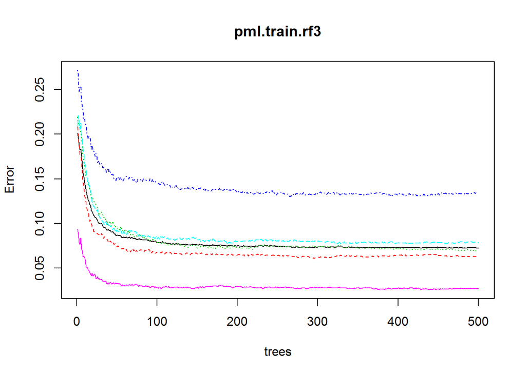

```r
plot(pml.train.rf3)
```

```r
pml.test.predict3 <- predict(pml.train.rf3,pml.test)
pml.test.predict
```

```
##  1  2  3  4  5  6  7  8  9 10 11 12 13 14 15 16 17 18 19 20
##  B  A  B  A  A  E  D  B  A  A  B  C  B  A  E  E  A  B  B  B
## Levels: A B C D E
```

```r
pml.test.predict3
```

```
##  1  2  3  4  5  6  7  8  9 10 11 12 13 14 15 16 17 18 19 20
##  B  A  B  A  A  E  D  B  A  A  B  C  B  A  E  E  A  B  B  B
## Levels: A B C D E
```

```r
pml.test.predict3==pml.test.predict
```

```
##  [1] TRUE TRUE TRUE TRUE TRUE TRUE TRUE TRUE TRUE TRUE TRUE TRUE TRUE TRUE
## [15] TRUE TRUE TRUE TRUE TRUE TRUE
```

Our cross validation is done automatically via fandomForest model that uses bootstraping.

Depending on needs accuracy vs. sensor data available different models could be chosen from above. For best accuracy we will chose model with most predictors.